# Swire Coca-Cola USA (SCCU) - Group Modeling Notebook

### Random Forest Model

```python
print(X.columns)
```

```
Index(['TRANS_COUNT_2023', 'ANNUAL_VOLUME_CASES_2023',
       'ANNUAL_VOLUME_GALLON_2023', 'ANNUAL_VOLUME_2023',
       'AVG_ORDER_VOLUME_2023', 'LOCAL_MARKET_PARTNER', 'CO2_CUSTOMER',
       'ZIP_CODE', 'DELIVERY_COST_2023_CASES', 'DELIVERY_COST_2023_GALLON',
       'DELIVERY_COST_2023', 'FREQUENT_ORDER_TYPE_EDI',
       'FREQUENT_ORDER_TYPE_MYCOKE LEGACY', 'FREQUENT_ORDER_TYPE_MYCOKE360',
       'FREQUENT_ORDER_TYPE_OTHER', 'FREQUENT_ORDER_TYPE_SALES REP',
       'COLD_DRINK_CHANNEL_BULK TRADE', 'COLD_DRINK_CHANNEL_CONVENTIONAL',
       'COLD_DRINK_CHANNEL_DINING', 'COLD_DRINK_CHANNEL_EVENT',
       'COLD_DRINK_CHANNEL_GOODS', 'COLD_DRINK_CHANNEL_PUBLIC SECTOR',
       'COLD_DRINK_CHANNEL_WELLNESS', 'COLD_DRINK_CHANNEL_WORKPLACE',
       'TRADE_CHANNEL_ACCOMMODATION', 'TRADE_CHANNEL_ACTIVITIES',
       'TRADE_CHANNEL_BULK TRADE', 'TRADE_CHANNEL_COMPREHENSIVE DINING',
       'TRADE_CHANNEL_DEFENSE', 'TRADE_CHANNEL_EDUCATION',
       'TRADE_CHANNEL_FAST CASUAL DINING', 'TRADE_CHANNEL_GENERAL',
       'TRADE_CHANNEL_GENERAL RETAILER', 'TRADE_CHANNEL_GOURMET FOOD RETAILER',
       'TRADE_CHANNEL_HEALTHCARE', 'TRADE_CHANNEL_INDUSTRIAL',
       'TRADE_CHANNEL_LARGE-SCALE RETAILER',
       'TRADE_CHANNEL_LICENSED HOSPITALITY', 'TRADE_CHANNEL_MOBILE RETAIL',
       'TRADE_CHANNEL_OTHER DINING & BEVERAGE',
       'TRADE_CHANNEL_OUTDOOR ACTIVITIES', 'TRADE_CHANNEL_PHARMACY RETAILER',
       'TRADE_CHANNEL_PROFESSIONAL SERVICES',
       'TRADE_CHANNEL_PUBLIC SECTOR (NON-MILITARY)',
       'TRADE_CHANNEL_RECREATION', 'TRADE_CHANNEL_SPECIALIZED GOODS',
       'TRADE_CHANNEL_SUPERSTORE', 'TRADE_CHANNEL_TRAVEL',
       'TRADE_CHANNEL_VEHICLE CARE', 'SUB_TRADE_CHANNEL_BOOKS & OFFICE',
       'SUB_TRADE_CHANNEL_BULK BEVERAGE RETAIL',
       'SUB_TRADE_CHANNEL_BULK TRADE', 'SUB_TRADE_CHANNEL_BURGER FAST FOOD',
       'SUB_TRADE_CHANNEL_CHAIN STORE', 'SUB_TRADE_CHANNEL_CHICKEN FAST FOOD',
       'SUB_TRADE_CHANNEL_CLUB', 'SUB_TRADE_CHANNEL_COMPREHENSIVE PROVIDER',
       'SUB_TRADE_CHANNEL_CRUISE', 'SUB_TRADE_CHANNEL_FAITH',
       'SUB_TRADE_CHANNEL_FRATERNITY', 'SUB_TRADE_CHANNEL_FSR - MISC',
       'SUB_TRADE_CHANNEL_GAME CENTER', 'SUB_TRADE_CHANNEL_HIGH SCHOOL',
       'SUB_TRADE_CHANNEL_HOME & HARDWARE',
       'SUB_TRADE_CHANNEL_INDEPENDENT LOCAL STORE',
       'SUB_TRADE_CHANNEL_MEXICAN FAST FOOD',
       'SUB_TRADE_CHANNEL_MIDDLE SCHOOL', 'SUB_TRADE_CHANNEL_MISC',
       'SUB_TRADE_CHANNEL_MOBILE RETAIL',
       'SUB_TRADE_CHANNEL_NON-RESTAURANT EDUCATION',
       'SUB_TRADE_CHANNEL_ONLINE STORE',
       'SUB_TRADE_CHANNEL_OTHER ACADEMIC INSTITUTION',
       'SUB_TRADE_CHANNEL_OTHER ACCOMMODATION',
       'SUB_TRADE_CHANNEL_OTHER DINING', 'SUB_TRADE_CHANNEL_OTHER FAST FOOD',
       'SUB_TRADE_CHANNEL_OTHER GENERAL RETAIL',
       'SUB_TRADE_CHANNEL_OTHER GOODS', 'SUB_TRADE_CHANNEL_OTHER GOURMET FOOD',
       'SUB_TRADE_CHANNEL_OTHER HEALTHCARE',
       'SUB_TRADE_CHANNEL_OTHER INDUSTRIAL',
       'SUB_TRADE_CHANNEL_OTHER LARGE RETAILER',
       'SUB_TRADE_CHANNEL_OTHER LICENSED HOSPITALITY',
       'SUB_TRADE_CHANNEL_OTHER MILITARY',
       'SUB_TRADE_CHANNEL_OTHER OUTDOOR ACTIVITIES',
       'SUB_TRADE_CHANNEL_OTHER PROFESSIONAL SERVICES',
       'SUB_TRADE_CHANNEL_OTHER PUBLIC SECTOR',
       'SUB_TRADE_CHANNEL_OTHER RECREATION', 'SUB_TRADE_CHANNEL_OTHER TRAVEL',
       'SUB_TRADE_CHANNEL_OTHER VEHICLE CARE',
       'SUB_TRADE_CHANNEL_PIZZA FAST FOOD', 'SUB_TRADE_CHANNEL_PRIMARY SCHOOL',
       'SUB_TRADE_CHANNEL_RECREATION ARENA',
       'SUB_TRADE_CHANNEL_RECREATION FILM',
       'SUB_TRADE_CHANNEL_RECREATION PARK', 'SUB_TRADE_CHANNEL_RESIDENTIAL',
       'SUB_TRADE_CHANNEL_SANDWICH FAST FOOD', 'STATE_SHORT_KY',
       'STATE_SHORT_LA', 'STATE_SHORT_MA', 'STATE_SHORT_MD'],
      dtype='object')
```

```
Confusion Matrix:
[[5836   61]
 [ 216   38]]

 Classification Report:
              precision    recall  f1-score   support

           0       0.96      0.99      0.98      5897
           1       0.38      0.15      0.22       254

    accuracy                           0.95      6151
   macro avg       0.67      0.57      0.60      6151
weighted avg       0.94      0.95      0.95      6151


 Accuracy Score:
0.9549666720858397
```

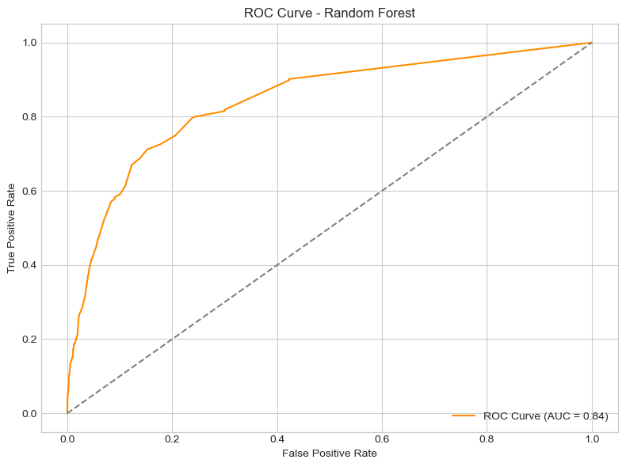

```python
# check for any leakages in the target variable
#print([col for col in X.columns if 'THRESHOLD' in col or 'GROWTH_READY' in col])


# Define the pipeline: imputation (for NA's) + random forest
pipeline = Pipeline([
    ('imputer', SimpleImputer(strategy='mean')),  # Replace missing values
    ('classifier', RandomForestClassifier(n_estimators=100, random_state=42))
])

# Train the model using the pipeline
pipeline.fit(X_train, y_train)

# Predict on test data
y_pred = pipeline.predict(X_test)
y_prob = pipeline.predict_proba(X_test)[:, 1]  # Probabilities for ROC curve

# Evaluate
print("Confusion Matrix:")
print(confusion_matrix(y_test, y_pred))

print("\n Classification Report:")
print(classification_report(y_test, y_pred))

print("\n Accuracy Score:")
print(accuracy_score(y_test, y_pred))

# ROC-AUC
roc_auc = roc_auc_score(y_test, y_prob)
fpr, tpr, _ = roc_curve(y_test, y_prob)

plt.figure(figsize=(8, 6))
plt.plot(fpr, tpr, label=f'ROC Curve (AUC = {roc_auc:.2f})', color='darkorange')
plt.plot([0, 1], [0, 1], linestyle='--', color='gray')
plt.xlabel("False Positive Rate")
plt.ylabel("True Positive Rate")
plt.title("ROC Curve - Random Forest")
plt.legend(loc="lower right")
plt.grid(True)
plt.tight_layout()
plt.show()
```

```
 Top 15 Important Features:
                          Feature  Importance
7                        ZIP_CODE    0.221298
3              ANNUAL_VOLUME_2023    0.087552
4           AVG_ORDER_VOLUME_2023    0.082434
10             DELIVERY_COST_2023    0.069633
1        ANNUAL_VOLUME_CASES_2023    0.060201
0                TRANS_COUNT_2023    0.058063
8        DELIVERY_COST_2023_CASES    0.054561
2       ANNUAL_VOLUME_GALLON_2023    0.039360
9       DELIVERY_COST_2023_GALLON    0.037506
6                    CO2_CUSTOMER    0.023296
15  FREQUENT_ORDER_TYPE_SALES REP    0.017694
96                 STATE_SHORT_KY    0.015539
98                 STATE_SHORT_MA    0.015404
5            LOCAL_MARKET_PARTNER    0.014893
99                 STATE_SHORT_MD    0.014684
```

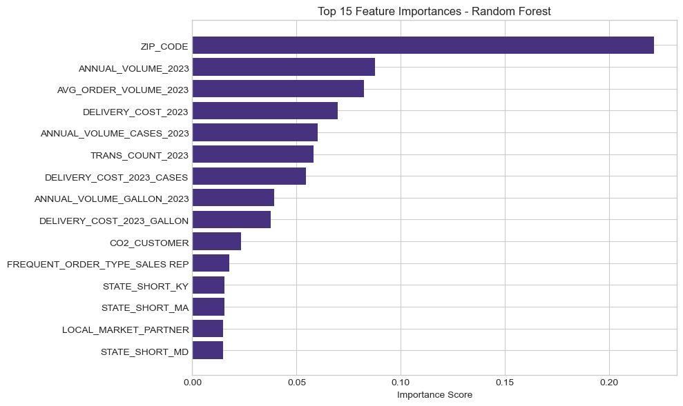

```python
### Which charecteristics drive the predictions

# Extract the trained model from pipeline
rf_model_gs = pipeline.named_steps['classifier']

# Get feature importances
importances = rf_model_gs.feature_importances_

# Map them to feature names
feature_names = X.columns
feat_imp_df = pd.DataFrame({'Feature': feature_names, 'Importance': importances})
feat_imp_df = feat_imp_df.sort_values(by='Importance', ascending=False)

# Show top 15 important features
print(" Top 15 Important Features:")
print(feat_imp_df.head(15))

# Plot
plt.figure(figsize=(10, 6))
plt.barh(feat_imp_df['Feature'].head(15), feat_imp_df['Importance'].head(15))
plt.gca().invert_yaxis()
plt.title('Top 15 Feature Importances - Random Forest')
plt.xlabel('Importance Score')
plt.tight_layout()
plt.show()
```

### GridSearchCV with Random Forest Classifier

```
Fitting 5 folds for each of 48 candidates, totalling 240 fits
Confusion Matrix:
[[5836   61]
 [ 216   38]]

 Classification Report:
              precision    recall  f1-score   support

           0       0.96      0.99      0.98      5897
           1       0.38      0.15      0.22       254

    accuracy                           0.95      6151
   macro avg       0.67      0.57      0.60      6151
weighted avg       0.94      0.95      0.95      6151


 Accuracy Score:
0.9549666720858397

 Best Hyperparameters:
{'classifier__max_depth': None, 'classifier__max_features': 'sqrt', 'classifier__min_samples_leaf': 1, 'classifier__min_samples_split': 2, 'classifier__n_estimators': 100}
```

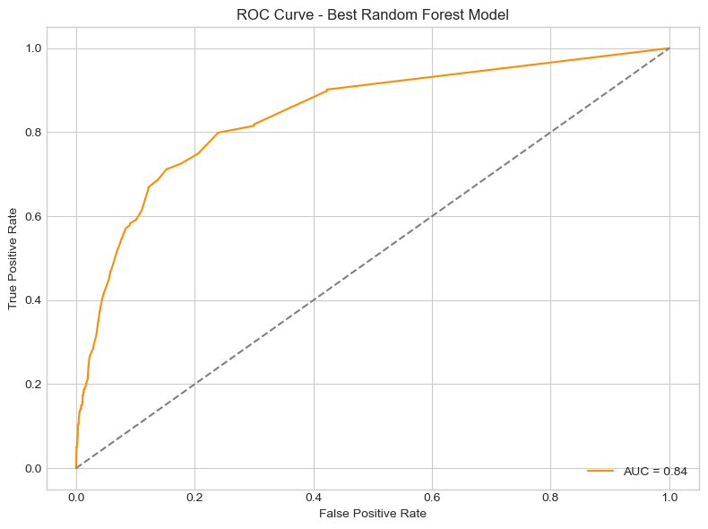

```python
# Define pipeline: impute NA's + RF model
pipeline = Pipeline([
    ('imputer', SimpleImputer(strategy='mean')),
    ('classifier', RandomForestClassifier(random_state=42))
])

# Define hyperparameter grid
#(note: prefix with classifier__ to access inside pipeline)
param_grid = {
    'classifier__n_estimators': [50, 100], #no. of trees
    'classifier__max_depth': [None, 5, 10],
    'classifier__min_samples_split': [2, 5],
    'classifier__min_samples_leaf': [1, 2],
    'classifier__max_features': ['sqrt', 'log2']
}

# Set up GridSearchCV
grid_search = GridSearchCV(estimator=pipeline, param_grid=param_grid,
                           cv=5, scoring='f1', n_jobs=-1, verbose=1)

# Fit model
grid_search.fit(X_train, y_train)

# Best model
best_model = grid_search.best_estimator_

# Predict on test set
y_pred = best_model.predict(X_test)
y_proba = best_model.predict_proba(X_test)[:, 1]  # get probabilities for class 1 (for ROC-AUC Curve)

# Evaluate
print("Confusion Matrix:")
print(confusion_matrix(y_test, y_pred))

print("\n Classification Report:")
print(classification_report(y_test, y_pred))

print("\n Accuracy Score:")
print(accuracy_score(y_test, y_pred))

# Get best parameters
print("\n Best Hyperparameters:")
print(grid_search.best_params_)


# Calculate ROC curve
fpr, tpr, thresholds = roc_curve(y_test, y_proba)

# Compute AUC
roc_auc = roc_auc_score(y_test, y_proba)

# Plot ROC Curve
plt.figure(figsize=(8, 6))
plt.plot(fpr, tpr, label=f"AUC = {roc_auc:.2f}", color='darkorange')
plt.plot([0, 1], [0, 1], linestyle='--', color='gray')
plt.xlabel('False Positive Rate')
plt.ylabel('True Positive Rate')
plt.title('ROC Curve - Best Random Forest Model')
plt.legend(loc='lower right')
plt.grid(True)
plt.tight_layout()
plt.show()
```

Both the Random Forest model and Random Forest with grid search achieved a ROC-AUC score of 0.84. The best random forest model used 100 trees with no depth limit, considered the square root of features at each split, and allowed nodes to split with at least 2 samples and leaves with at least 1 sample.

### GradientBoosting(Using XGBoost) with GridSearch

```
Fitting 5 folds for each of 16 candidates, totalling 80 fits
Confusion Matrix:
[[5869   28]
 [ 234   20]]

 Classification Report:
              precision    recall  f1-score   support

           0       0.96      1.00      0.98      5897
           1       0.42      0.08      0.13       254

    accuracy                           0.96      6151
   macro avg       0.69      0.54      0.56      6151
weighted avg       0.94      0.96      0.94      6151


 Accuracy Score:
0.9574052999512275

 ROC AUC Score: 0.8954
```

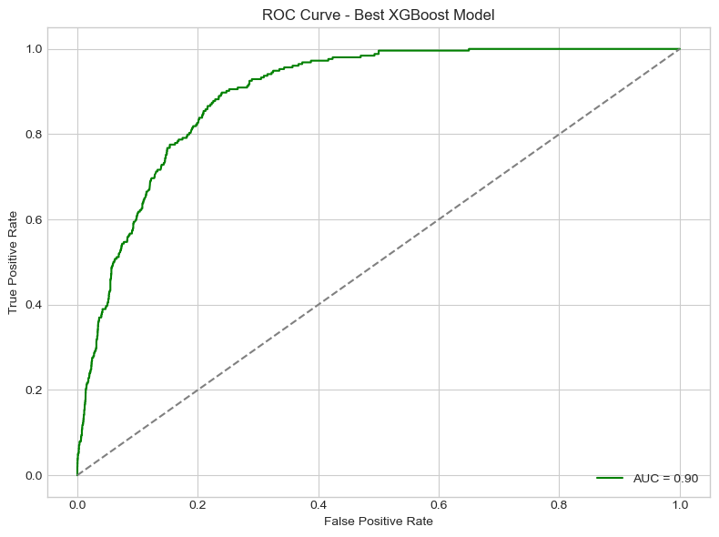

```python
# Define parameter grid for XGBoost
param_grid_xgb = {
    'n_estimators': [50, 100],
    'max_depth': [3, 5],
    'learning_rate': [0.02, 0.1],
    'subsample': [0.8, 1.0]
}

# Create xgboost model
xgb_clf = xgb.XGBClassifier(
    random_state=42,
    eval_metric='logloss'
)

# Set up GridSearchCV
grid_search_xgb = GridSearchCV(estimator=xgb_clf, param_grid=param_grid_xgb,
                                cv=5, scoring='f1', verbose=1, n_jobs=-1)

# Fit the model
grid_search_xgb.fit(X_train, y_train)

#  Get the best model
best_xgb = grid_search_xgb.best_estimator_

# Predict on test set from best model
y_pred_xgb = best_xgb.predict(X_test)
y_proba_xgb = best_xgb.predict_proba(X_test)[:, 1]

# Evaluation Metrics
print("Confusion Matrix:")
print(confusion_matrix(y_test, y_pred_xgb))

print("\n Classification Report:")
print(classification_report(y_test, y_pred_xgb))

print("\n Accuracy Score:")
print(accuracy_score(y_test, y_pred_xgb))

# ROC-AUC
roc_auc = roc_auc_score(y_test, y_proba_xgb)
print(f"\n ROC AUC Score: {roc_auc:.4f}")

# Plot ROC Curve
fpr, tpr, _ = roc_curve(y_test, y_proba_xgb)
plt.figure(figsize=(8, 6))
plt.plot(fpr, tpr, label=f"AUC = {roc_auc:.2f}", color='green')
plt.plot([0, 1], [0, 1], linestyle='--', color='gray')
plt.xlabel('False Positive Rate')
plt.ylabel('True Positive Rate')
plt.title('ROC Curve - Best XGBoost Model')
plt.legend(loc='lower right')
plt.grid(True)
plt.tight_layout()
plt.show()
```

```python
# Best parameters from XGboost gridsearch

print("\n Best Hyperparameters from GridSearchCV:")
print(grid_search_xgb.best_params_)
```

```
 Best Hyperparameters from GridSearchCV:
{'learning_rate': 0.1, 'max_depth': 5, 'n_estimators': 100, 'subsample': 0.8}
```

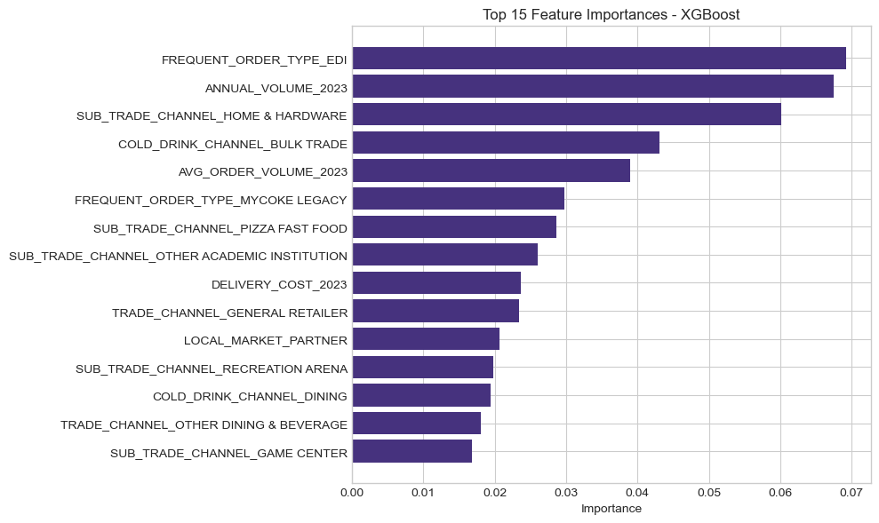

```python
# Feature importance
importances = best_xgb.feature_importances_
feature_names = X.columns
feat_imp_df = pd.DataFrame({'Feature': feature_names, 'Importance': importances})
feat_imp_df = feat_imp_df.sort_values(by='Importance', ascending=False)

# Plot
plt.figure(figsize=(10, 6))
plt.barh(feat_imp_df['Feature'][:15], feat_imp_df['Importance'][:15])
plt.gca().invert_yaxis()
plt.title('Top 15 Feature Importances - XGBoost')
plt.xlabel('Importance')
plt.tight_layout()
plt.show()
```

Out of the 3 models built, the XGBoost using grid search performed the best with an ROC-AUC of 0.89. The best XGBoost model achieved optimal performance with a learning rate of 0.1, using 100 trees of maximum depth 5.

Customers who frequently use EDI (Electronic Data Interchange) for ordering are strong indicators of growth readiness. Features like ANNUAL_VOLUME_2023 and AVG_ORDER_VOLUME_2023 indicate that customers with steady (but not necessarily high) volumes and efficient, larger order sizes tend to grow more over time. Belonging to Bulk Trade and Pizza/Fast Food, Home/Hardware chains is a strong indicator of growth-readiness too. Being a local market partner and having reasonable delivery costs in 2023 also contribute positively to know whether the customer is growth-ready.